# Fare prediction

### 1 Problem Statement

The predicting of fare amount (inclusive of tolls) for a taxi ride, given the pickup and dropoff locations,the pickup date time and many other attributes given below. The description of all the attributes is given below. The target variable is “fare_amount “

Understand the data and do necessary data exploration and try creating new features and build a machine learning model to predict the fare amount.

| **Variable** | **Description** |
| --- | --- |
| TID | Unique ID |
| Vendor_ID | Technology service vendor associated with cab company |
| New_User | If a new user is taking the ride |
| toll_price | toll tax amount |
| tip_amount | tip given to driver (if any) |
| tax | applicable tax |
| pickup_timestamp | time at which the ride started |
| dropoff_timestamp | time at which ride ended |
| passenger_count | number of passenger during the ride |
| pickup_longitude | pickup location longitude data |
| pickup_latitude | pickup location latitude data |
| rate_category | category assigned to different rates at which a customer is charged |
| store_and_fwd | if driver stored the data offline and later forwarded |
| dropoff_longitude | drop off longitude data |
| dropoff_latitude | drop off latitude data |
| payment_type | payment mode used by the customer (CRD = Credit Card, CSH - Cash, DIS - dispute, NOC - No Charge, UNK - Unknown) |
| surcharge | surchage applicable on the trip |
| fare_amount | trip fare (to be predicted) |

Information on rate category can be feteched from the official website of NYC cabs : https://www1.nyc.gov/site/tlc/passengers/taxi-fare.page  
Rate #01 – Standard City Rate within the City limit.  
Rate #02 - Trips to JFK Airport.  
Rate #03 - Trips to Newark Airport.  
Rate #04 - Out of City Rate to Nassau or Westchester.  
Rate #05 - Out of City Negotiated Flat Rate.

```python
#Library : https://geopandas.org/
# from global_land_mask import globe
# import numpy as np
```

```python
# !pip install global_land_mask
# !pip install countries
# !pip install H3
```

```python
import pandas as pd
import seaborn as sns
import matplotlib.pyplot as plt
import datetime
from tqdm import tqdm
import haversine as hs
%matplotlib inline
import warnings
warnings.filterwarnings('ignore')
```

```python
data = pd.read_csv('train.csv')
# test_data = pd.read_csv('test.csv')
```

```python
data.shape
```

```
(119386, 18)
```

```python
data.dtypes
```

```
TID                    object
vendor_id              object
new_user               object
tolls_amount          float64
tip_amount            float64
mta_tax               float64
pickup_datetime        object
dropoff_datetime       object
passenger_count         int64
pickup_longitude      float64
pickup_latitude       float64
rate_code               int64
store_and_fwd_flag     object
dropoff_longitude     float64
dropoff_latitude      float64
payment_type           object
surcharge             float64
fare_amount           float64
dtype: object
```

```python
data.describe()
```

|  | tolls_amount | tip_amount | mta_tax | passenger_count | pickup_longitude | pickup_latitude | rate_code | dropoff_longitude | dropoff_latitude | surcharge | fare_amount |
| --- | --- | --- | --- | --- | --- | --- | --- | --- | --- | --- | --- |
| count | 119386.000000 | 107499.000000 | 119386.000000 | 119386.000000 | 115831.000000 | 116984.000000 | 119386.000000 | 119022.000000 | 118820.000000 | 112219.000000 | 119386.000000 |
| mean | 0.273719 | 1.556543 | 0.497952 | 1.722396 | -72.611889 | 40.004528 | 1.034686 | -72.624875 | 40.008286 | 0.317945 | 15.306157 |
| std | 1.283236 | 2.377861 | 0.033030 | 1.386579 | 9.948813 | 5.464661 | 0.273578 | 9.900074 | 5.452794 | 0.362051 | 12.733168 |
| min | 0.000000 | 0.000000 | -0.500000 | 0.000000 | -99.083115 | -13.551884 | 0.000000 | -99.083115 | -13.551884 | -1.000000 | 0.000000 |
| 25% | 0.000000 | 0.000000 | 0.500000 | 1.000000 | -73.991916 | 40.735188 | 1.000000 | -73.991392 | 40.733734 | 0.000000 | 8.300000 |
| 50% | 0.000000 | 1.000000 | 0.500000 | 1.000000 | -73.981682 | 40.752767 | 1.000000 | -73.979965 | 40.753029 | 0.000000 | 11.500000 |
| 75% | 0.000000 | 2.100000 | 0.500000 | 2.000000 | -73.966937 | 40.767167 | 1.000000 | -73.962746 | 40.768330 | 0.500000 | 17.000000 |
| max | 30.000000 | 98.550000 | 0.500000 | 6.000000 | 0.000000 | 50.514841 | 6.000000 | 0.000000 | 42.253078 | 2.500000 | 480.000000 |

```python
data.dtypes
```

```
TID                    object
vendor_id              object
new_user               object
tolls_amount          float64
tip_amount            float64
mta_tax               float64
pickup_datetime        object
dropoff_datetime       object
passenger_count         int64
pickup_longitude      float64
pickup_latitude       float64
rate_code               int64
store_and_fwd_flag     object
dropoff_longitude     float64
dropoff_latitude      float64
payment_type           object
surcharge             float64
fare_amount           float64
dtype: object
```

```python
data.isnull().sum()
```

```
TID                       0
vendor_id                 0
new_user                  1
tolls_amount              0
tip_amount            11887
mta_tax                   0
pickup_datetime           0
dropoff_datetime          0
passenger_count           0
pickup_longitude       3555
pickup_latitude        2402
rate_code                 0
store_and_fwd_flag    46712
dropoff_longitude       364
dropoff_latitude        566
payment_type              0
surcharge              7167
fare_amount               0
dtype: int64
```

## 2 Exploratory Data Analysis (on raw data)

### 2.1 Correlation Plot

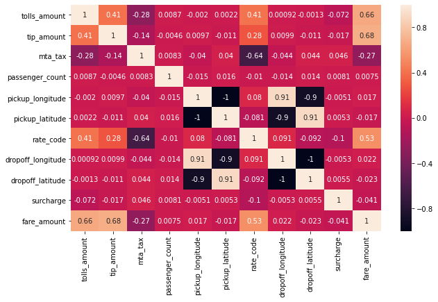

```python
plt.figure(figsize=(10,6))
sns.heatmap(data.corr(),annot=True)
```

From the above correlation plot we can see a very strong negative correlation, between

dropoff_longitude & dropoff_latitude = -1.0

pickup_longitude & dropoff_latitude = -0.9

pickup_latitude & dropoff_longitude = -0.9

which means they're inversly proportional to each other i.e if the value of feature A increases then the value of feature B decreases and vice versa.

### 2.2 Univariate Analysis

#### 2.2.1 Numerical Variables

###### 2.2.1.1 tolls_amount

```
Toll Amount Histogram
```

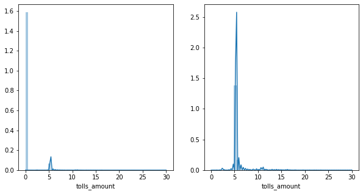

```python
print("Toll Amount Histogram")
plt.figure(figsize=(10,5))

plt.subplot(1, 2, 1)
sns.distplot(data['tolls_amount'])

plt.subplot(1, 2, 2)
sns.distplot(data['tolls_amount'][data['tolls_amount']>0])
```

Left (With zero's): We can see there are lots of zero values in the toll_amount column but it can be assumed that the route didn't have any toll booth's.

Right (Without zero's): There is some Positive Skewness

##### 2.2.1.2 tip_amount

```
Tip Amount Histogram
```

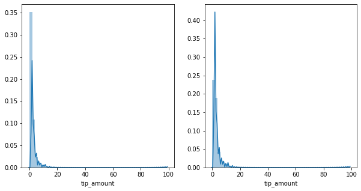

```python
print("Tip Amount Histogram")
# sns.distplot(data.tip_amount.dropna())

plt.figure(figsize=(10,5))

plt.subplot(1, 2, 1)
sns.distplot(data['tip_amount'].dropna())

plt.subplot(1, 2, 2)
sns.distplot(data['tip_amount'][data['tip_amount']>0].dropna())
```

Right (Without zero's): There is some Positive Skewness.

##### 2.2.1.3 mta_tax

```
Tax Histogram
```

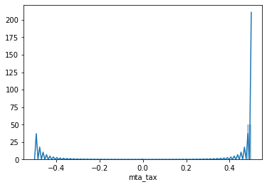

```python
print("Tax Histogram")
sns.distplot(data.mta_tax)
```

##### 2.2.1.4 passenger_count

```
Passenger Count Histogram
```

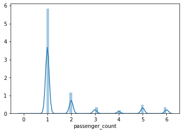

```python
print("Passenger Count Histogram")
sns.distplot(data.passenger_count)
```

Mostly taxis are occuppied by a single person

##### 2.2.1.5 pickup_longitude & 2.2.1.6 pickup_latitude

```
pickup_longitude & pickup_latitude Histogram
```

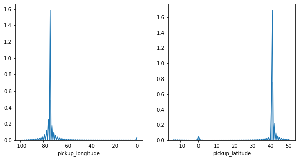

```python
print("pickup_longitude & pickup_latitude Histogram")
# sns.distplot(data.tip_amount.dropna())

plt.figure(figsize=(10,5))

plt.subplot(1, 2, 1)
sns.distplot(data['pickup_longitude'].dropna())

plt.subplot(1, 2, 2)
sns.distplot(data['pickup_latitude'].dropna())
```

##### 2.2.1.7 dropoff_longitude 2.2.1.9 dropoff_latitude

```
dropoff_longitude & dropoff_latitude Histogram
```

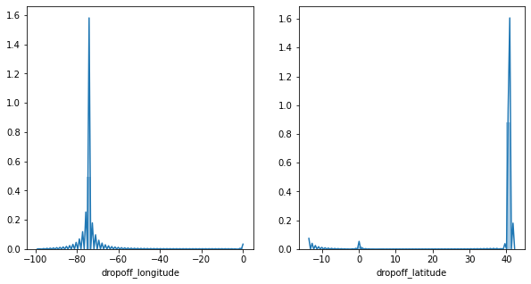

```python
print("dropoff_longitude & dropoff_latitude Histogram")
# sns.distplot(data.tip_amount.dropna())

plt.figure(figsize=(10,5))

plt.subplot(1, 2, 1)
sns.distplot(data['dropoff_longitude'].dropna())

plt.subplot(1, 2, 2)
sns.distplot(data['dropoff_latitude'].dropna())
```

##### 2.2.1.10 surcharge

```
Surcharge Histogram
 0.0    57251
 0.5    38570
 1.0    16383
 1.5        7
-0.5        5
-1.0        1
 2.5        1
 2.0        1
Name: surcharge, dtype: int64
```

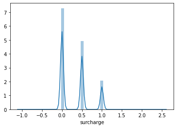

```python
print("Surcharge Histogram")
sns.distplot(data.surcharge.dropna())
print(data.surcharge.value_counts())
```

##### 2.2.1.11 fare_amount

```
Fare Amount Histogram
```

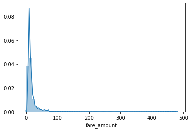

```python
print("Fare Amount Histogram")
sns.distplot(data.fare_amount.dropna())
```

Fare Amount is also right skewed so regression methods will not be able to produce accurate results.

#### 2.2.2 Categorical Variables

##### 2.2.2.1 vendor_id

```
Vender Countplot
```

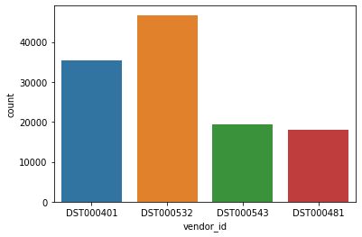

```python
print("Vender Countplot")
sns.countplot(data.vendor_id)
```

Vendor DST000532 has most taxi fares

##### 2.2.2.2 new_user

```
New User Countplot
NO     119368
YES        17
Name: new_user, dtype: int64
```

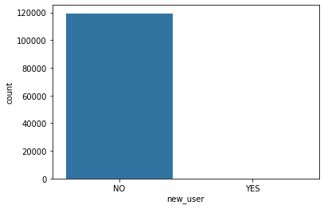

```python
print("New User Countplot")
sns.countplot(data.new_user)
print(data.new_user.value_counts())
```

There are only 17 new users and the other 119368 are old customers.

##### 2.2.2.3 store_and_fwd_flag

```
Offline data Countplot
N    71582
Y     1092
Name: store_and_fwd_flag, dtype: int64
```

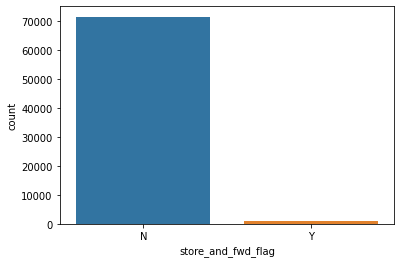

```python
print("Offline data Countplot")
sns.countplot(data.store_and_fwd_flag)
print(data.store_and_fwd_flag.value_counts())
```

Offline stored data has 71582 No values and 1092 Yes values. These 1092 values can have inconsistent values.

##### 2.2.2.4 payment_type

```
Payment Type Countplot
CRD    71164
CSH    47422
UNK      395
NOC      305
DIS      100
Name: payment_type, dtype: int64
```

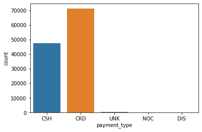

```python
print("Payment Type Countplot")
sns.countplot(data.payment_type)
print(data.payment_type.value_counts())
```

Customers prefer online payment method more than any other transactions

##### 2.2.2.5 rate_code

```
Rate Code Countplot
1    116585
2      2210
5       359
3       191
4        37
0         3
6         1
Name: rate_code, dtype: int64
```

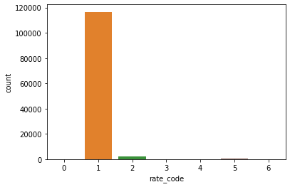

```python
print("Rate Code Countplot")
sns.countplot(data.rate_code)
print(data.rate_code.value_counts())
```

### 2.3 Bivariate Analysis

#### 2.3.1 Numerical Variables vs Numerical Variables

##### 2.3.1.1 fare_amount vs tolls_amount

```
fare_amount vs tolls_amount
```

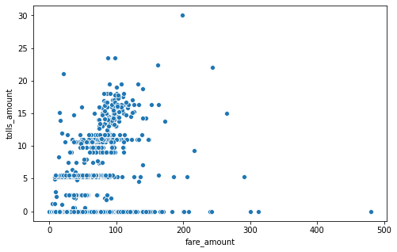

```python
plt.figure(figsize=(8,5))
print("fare_amount vs tolls_amount")
sns.scatterplot(x=data.fare_amount, y=data.tolls_amount)
```

##### 2.3.1.2 fare_amount vs tip_amount

```
fare_amount vs tip_amount
```

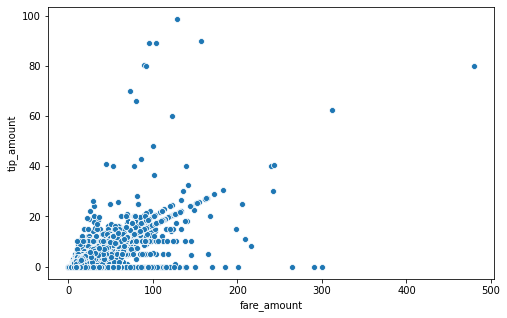

```python
plt.figure(figsize=(8,5))
print("fare_amount vs tip_amount")
sns.scatterplot(x=data.fare_amount, y=data.tip_amount)
```

## 3 Thought Process

- Removal of negative surcharge and MTA tax values.
- NA values : new_user - 1 , tip_amount - 11887 , pickup_longitude - 3555 , pickup_latitude - 2402 , store_and_fwd_flag - 46712 , dropoff_longitude - 364 , dropoff_latitude - 566 , surcharge - 7167.
- Filter values from latitude and longitude with inconsistent values
- Create a new column named distance using pickup and dropoff locations
- Seperate the column pickup_datetime and dropoff_datetime and create new attributes.

#### 3.1 Removal of Negative Tax values and handling NA Values.

Negative Surcharge values and mta tax makes no sense so we can get rid of the rows containing negative values.

```python
#Removing negative Surcharge values
data = data[data['surcharge']>=0]

#Removing negative mta tax values
data = data[data['mta_tax']>=0]
```

```python
# Imputing new user value with mode
data['new_user'].fillna(data['new_user'].mode()[0], inplace = True)

# Imputing tip_amount with the mean
data['tip_amount'].fillna(data['tip_amount'].mean(), inplace = True)

# Removing rows with NA values from column pickup_longitude, pickup_latitude,dropoff_longitude, dropoff_latitude
data.dropna(subset=['pickup_longitude', 'pickup_latitude','dropoff_longitude','dropoff_latitude'],inplace=True)

# Removing column store_and_fwd_flag
data.drop('store_and_fwd_flag',axis=1,inplace=True)

# Imputing surcharge missing values
```

#### 3.2 Latitude and Longitude of pick up and drop off locations

Removing "Null Island" Coordinate 0

According to wikipedia (https://en.wikipedia.org/wiki/Null_Island) Null Island is the name used to refer to the point on the Earth's surface where the Prime Meridian and the Equator intersect, at zero degrees latitude and zero degrees longitude (0°N 0°E). Using the WGS84 datum, this point is located in international waters in the Gulf of Guinea, in the Atlantic Ocean, off the coast of West Africa.

```python
# Removing rows with Latitude and Longitude of pickup and drop-off = 0
data = data[(data['pickup_longitude']!=0) & (data['pickup_latitude']!=0)]
data = data[(data['dropoff_longitude']!=0) & (data['dropoff_latitude']!=0)]
```

```python
data.reset_index(inplace=True,drop=True)
```

We can add a new column with pickup country and state & dropoff country and state to find outliers and inconsistent data

```python
import reverse_geocoder as rg
# For pick up
coordinates = tuple(zip(data['pickup_latitude'], data['pickup_longitude']))
results_rg = rg.search(coordinates)
pickup_country = [x.get('cc') for x in results_rg]
pickup_state = [x.get('admin1') for x in results_rg]

# For Drop off
coordinates = tuple(zip(data['dropoff_latitude'], data['dropoff_longitude']))
results_rg = rg.search(coordinates)
dropoff_country = [x.get('cc') for x in results_rg]
dropoff_state = [x.get('admin1') for x in results_rg]

data['pickup_country'] = pickup_country
data['pickup_state'] = pickup_state
data['dropoff_country'] = dropoff_country
data['dropoff_state'] = dropoff_state
```

What reverse_geocoder actually does is it fetches the nearest country no matter how far. The coordinates which belong to different countries have to be checked.

```python
# Checing inconsistent data in dropoff_country
data[data['dropoff_country']!="US"]
```

|  | TID | vendor_id | new_user | tolls_amount | tip_amount | mta_tax | pickup_datetime | dropoff_datetime | passenger_count | pickup_longitude | ... | rate_code | dropoff_longitude | dropoff_latitude | payment_type | surcharge | fare_amount | pickup_country | pickup_state | dropoff_country | dropoff_state |
| --- | --- | --- | --- | --- | --- | --- | --- | --- | --- | --- | --- | --- | --- | --- | --- | --- | --- | --- | --- | --- | --- |
| 86208 | AIX0001723568 | DST000481 | NO | 0.0 | 1.66 | 0.5 | 2016-02-04 15:13:21 | 2016-02-04 15:21:40 | 1 | -99.083115 | ... | 1 | -99.083115 | -13.551884 | CRD | 0.0 | 9.96 | EC | Galapagos | EC | Galapagos |
| 97701 | AIX0001906507 | DST000481 | NO | 0.0 | 0.00 | 0.5 | 2016-04-23 17:56:05 | 2016-04-23 17:59:27 | 1 | -38.912590 | ... | 1 | -38.944321 | 36.726768 | CSH | 1.0 | 6.30 | PT | Azores | PT | Azores |

2 rows × 21 columns

There are 2 points which are outliers.

```python
from global_land_mask import globe
print(globe.is_ocean(data['pickup_latitude'][86208], data['pickup_longitude'][86208]))
print(globe.is_ocean(data['dropoff_latitude'][97701], data['dropoff_longitude'][97701]))
```

```
True
True
```

After using global_land_mask we can see that these points are outliers and are coordinates on ocean and not on land. Deleting these 2 records.

```python
data=data[data['dropoff_country']=="US"]
```

```python
#Checking inconsistent data in pickup
data[data['pickup_country']!="US"]
```

|  | TID | vendor_id | new_user | tolls_amount | tip_amount | mta_tax | pickup_datetime | dropoff_datetime | passenger_count | pickup_longitude | ... | rate_code | dropoff_longitude | dropoff_latitude | payment_type | surcharge | fare_amount | pickup_country | pickup_state | dropoff_country | dropoff_state |
| --- | --- | --- | --- | --- | --- | --- | --- | --- | --- | --- | --- | --- | --- | --- | --- | --- | --- | --- | --- | --- | --- |
| 45417 | AIX0001071884 | DST000401 | NO | 0.0 | 0.0 | 0.5 | 2015-08-30 20:31:06 | 2015-08-30 20:41:15 | 2 | -81.169787 | ... | 1 | -73.992595 | 40.721399 | CSH | 0.5 | 10.0 | CA | Ontario | US | New York |

1 rows × 21 columns

There is fare which starts from Canada Ontario and it ends in New York US and the fare cost is only 10$. Also from pickup & dropoff datetime we can see that the ride duration was 10 minute and 9 secs which is impossible.

```python
import requests
import json
# call the OSMR API
r = requests.get(f"http://router.project-osrm.org/route/v1/car/"+str(data['pickup_longitude'][45417])+","+str(data['pickup_latitude'][45417])+";"+str(data['dropoff_longitude'][45417])+","+str(data['dropoff_latitude'][45417])+"?overview=false""")
# then you load the response using the json libray
# by default you get only one alternative so you access 0-th element of the `routes`
routes = json.loads(r.content)
route_1 = routes.get("routes")[0]

# https://towardsdatascience.com/driving-distance-between-two-or-more-places-in-python-89779d691def#1c17
```

```python
route_1['distance']
```

```
1627464.5
```

```python
route_1['duration']
```

```
83724.5
```

```python
#Deleting the record
data=data[data['pickup_country']=="US"]
```

```python
# requests.get(f"http://router.project-osrm.org/route/v1/car/-81.1698,50.5148;-73.9926,40.7214?overview=false")
```

Removing the new columns as we have used them to get rid of outliers.

```python
# data.drop()
```

```python
data.reset_index(inplace = True, drop = True)
```

#### 3.3 Creating new attributes from pickup_datetime and dropoff_datetime

##### 3.3.1 Calculating duration from given datetime

```python
# Converting the datatype from object to datetime
data['pickup_datetime'] = pd.to_datetime(data['pickup_datetime'])
data['dropoff_datetime'] = pd.to_datetime(data['dropoff_datetime'])
```

```python
# Converting datetime to duration in seconds
ride_duration_secs=[]
for i in range(data.shape[0]):
    time_interval = data["dropoff_datetime"][i] - data["pickup_datetime"][i]
    ride_duration_secs.append(time_interval.total_seconds())
data['ride_duration_secs'] = ride_duration_secs
```

```python
#Creating a new column to store the time of day data
part_of_day = data['ride_duration_secs']
```

##### 3.3.2 Calculating hour of the day to determine at which time of day the cab was booked

```python
# Creating a new column called pickup_hour to find part of the day
pickup_hour = []
for i in range(data.shape[0]):
    pickup_hour.append(datetime.datetime.strptime(str(data["dropoff_datetime"][i]),'%Y-%m-%d %H:%M:%S').hour)
data['pickup_hour'] = pickup_hour
```

```python
data['part_of_day'] = data['pickup_hour']
data['part_of_day'] = (data['pickup_hour'] % 24 + 4) // 4
data['part_of_day'].replace({1: 'Late Night',
                      2: 'Early Morning',
                      3: 'Morning',
                      4: 'Noon',
                      5: 'Evening',
                      6: 'Night'}, inplace=True)
```

##### 3.3.3 Creating a new column day to determine which day of the week the cab was booked

```python
#weekday() Returns the day of the week as an integer, where Monday is 0 and Sunday is 6.
week_day = []
for i in range(data.shape[0]):
    week_day.append(datetime.datetime.strptime(str(data["dropoff_datetime"][i]),'%Y-%m-%d %H:%M:%S').weekday())
data['weekday'] = week_day
data['weekday'].replace({0: 'Monday',
                      1: 'Tuesday',
                      2: 'Wednesday',
                      3: 'Thursday',
                      4: 'Friday',
                      5: 'Saturday',
                      6:'Sunday'}, inplace=True)
```

Since we have converted the datetime to duration we can get rid of the columns pickup_datetime and dropoff_datetime

```python
# Removing column dropoff_datetime & pickup_datetime
data.drop(['dropoff_datetime','pickup_datetime'],axis=1,inplace=True)
# data.drop('',axis=1,inplace=True)
```

```python
data.drop('pickup_hour',axis=1,inplace=True)
```

#### 3.3 Creating new attributes distance from pickup and dropoff latitudes and longitudes

Euclidean Distance works for the flat surface like a Cartesian plain however, Earth is not flat. So we have to use a special type of formula known as Haversine Distance.

```python
import haversine as hs
distance_in_meters = []
for i in range(data.shape[0]):
    pick=(data['pickup_longitude'][i],data['pickup_latitude'][i])
    drop=(data['dropoff_longitude'][i],data['dropoff_latitude'][i])
    distance_in_meters.append(hs.haversine(pick,drop,unit='m'))
data['distance_in_meters'] = distance_in_meters
```

Alternative Approach to calculate the distance travelled by a taxi which is more accurate than the Haversine Distance because the distance is calculated by open street map's open source api which calculates the route taken to reach the destination by car. But this approach is time consuming as well.

```python
# distance_covered = []
# for i in tqdm(range(data.shape[0])):
#     r = requests.get(f"https://routing.openstreetmap.de/routed-car/route/v1/driving/"+str(data['pickup_longitude'][i])+","+str(data['pickup_latitude'][i])+";"+str(data['dropoff_longitude'][i])+","+str(data['dropoff_latitude'][i])+"?overview=false""")
#     routes = json.loads(r.content)
#     route_1 = routes.get("routes")[0]
#     distance_covered.append(route_1['distance'])
```

We can get rid of latitude and longitude values since we have fetched the necessary information and we no longer require them.

```python
#Removing columns pickup_longitude,pickup_latitude & dropoff_longitude,dropoff_latitude
data.drop(['pickup_longitude','pickup_latitude','dropoff_longitude','dropoff_latitude'],axis=1,inplace = True)
```

##### Removing Unnecessary columns

```python
data.drop(['TID','new_user','pickup_country','pickup_state','dropoff_country','dropoff_state'],axis=1,inplace=True)
```

### 4. Dummify Categorical Variables

```python
categorical_variables = ['vendor_id','rate_code','payment_type','part_of_day','weekday']
```

```python
for col in categorical_variables:
    data[col] = data[col].astype('category')
```

```python
data = pd.get_dummies(data)
```

### 5. Model Building

```python
from sklearn.linear_model import LinearRegression
from sklearn.metrics import mean_squared_error,r2_score,mean_absolute_error
from sklearn.model_selection import GridSearchCV
from sklearn.model_selection import RandomizedSearchCV
from sklearn.ensemble import RandomForestRegressor
from sklearn.tree import DecisionTreeRegressor
import numpy as np
```

```python
from sklearn.model_selection import train_test_split
x=data.drop(['fare_amount'],axis=1)
y=data['fare_amount']
xTrain, xTest, yTrain, yTest = train_test_split(x, y, test_size = 1/3, random_state = 0)
```

#### 5.1 Linear Regression

```python
linearRegressor = LinearRegression(normalize=False)
linearRegressor.fit(xTrain, yTrain)
yPrediction = linearRegressor.predict(xTest)
r_square = linearRegressor.score(xTest, yTest)
mse = mean_squared_error(yPrediction, yTest)
rmse = mse ** 0.5
print(rmse)
print(r_square)
```

```
6.594585418343387
0.7107506293847279
```

#### 5.2 Random Forest

```python
clf = RandomForestRegressor(n_estimators=20)
clf.fit(xTrain, yTrain)
yPrediction = clf.predict(xTest)
r_square = clf.score(xTest, yTest)
mse = mean_squared_error(yPrediction, yTest)
rmse = mse ** 0.5
print(rmse)
print(r_square)
```

```
3.195194604970391
0.9320965163928272
```

#### 5.3 Decision Tree

```python
param_grid = {'max_depth': np.arange(3, 10)}
tree = GridSearchCV(DecisionTreeRegressor(), param_grid,refit=True)
tree.fit(xTrain, yTrain)
yPrediction = tree.predict(xTest)
r_square = tree.score(xTest, yTest)
mse = mean_squared_error(yPrediction, yTest)
rmse = mse ** 0.5
print(rmse)
print(r_square)
```

```
4.766005697349956
0.8489201513585806
```

We can see that by using the above approach the best model for the fare prediction is Random Forest with the accuracy of 93%